# Code Companion: Mastering R for Data Science 2026

Vadim Tyuryaev

April 11, 2026

# 1 Basics

## 1.1 Assign and Retrieve Values

Utilize `assign()` and `get()` in loops when dealing with a dynamic number of variables.

```r
# assign the value of 2 to a newly created variable called var.1
assign(paste("var", 1, sep="."),2)

# retrive the value of the var.1 variable
get("var.1")
```

```
#> [1] 2
```

```r
set.seed(as.numeric(as.Date("1777-04-30")))

# Create a data frame directly
my_data = data.frame(
  id = paste("rval", 1:5, sep = "_"),
  value = rnorm(5)
)

print(my_data)
```

```
#>       id      value
#> 1 rval_1  0.0475086
#> 2 rval_2  1.0277163
#> 3 rval_3 -1.4956767
#> 4 rval_4 -1.2280738
#> 5 rval_5 -0.1876937
```

## 1.2 Environment Scoping

Create custom environments to control where R looks for variables, leveraging parent-child links.

```r
defaults      = new.env()
defaults$tax  = 0.15

order         = new.env(parent = defaults)
order$price   = 200

# 'tax' is not in 'order', but is found via its parent environment
order$total   = order$price * (1 + get("tax", envir = order))
order$total
```

```
#> [1] 230
```

```r
# Create a parent environment
parent.env = new.env()

# Add some variables to the parent environment
parent.env$a = 10
parent.env$b = 5

# A simple calculation in the parent environment
parent.env$sum_parent = parent.env$a + parent.env$b   # 15

# Check what's in the global environment (you should NOT see a, b, or sum_parent)
ls()                # default is ls(globalenv())
```

```
#> [1] "defaults"   "my_data"    "order"      "parent.env" "var.1"
```

```r
# Check what's inside parent.env
ls(parent.env)
```

```
#> [1] "a"          "b"          "sum_parent"
```

```r
# [1] "a" "b" "sum_parent"

# Try to access 'a' from the global environment (this should give an error)
try(a, silent = FALSE)
```

```
#> Error in eval(expr, envir) : object 'a' not found
```

```r
# Error: object 'a' not found

# Correct way: explicitly get 'a' from parent.env
get("a", envir = parent.env)        # 10
```

```
#> [1] 10
```

## 1.3 Evaluate Expressions

Dynamically construct and evaluate expressions from strings, or extract data from model calls.

```r
# Define an expression
expr = expression(sqrt(81))

# Evaluate the expression
result = eval(expr)

# Print the result
print(result)
```

```
#> [1] 9
```

```r
# Dynamically construct an expression
x = 12
operation = "x ** 2"
expr = parse(text = operation)

# Evaluate the dynamically constructed expression
result = eval(expr)

# Print the result (returns 144)
print(result)
```

```
#> [1] 144
```

```r
set.seed(42)

lm.data  = data.frame(x = 1:10, y = 2.5 * (1:10) + rnorm(10))
lm.model = lm(y ~ x, data = lm.data)

# Extract the original data frame via the stored call
head(eval(lm.model$call$data), 3)
```

|  | x | y |
| --- | --- | --- |
| 1 | 1 | 3.870958 |
| 2 | 2 | 4.435302 |
| 3 | 3 | 7.863128 |

## 1.4 For Loops and Preallocation

```r
# basic usage
for (i in 1:10){
  print(i)
}
```

```
#> [1] 1
#> [1] 2
#> [1] 3
#> [1] 4
#> [1] 5
#> [1] 6
#> [1] 7
#> [1] 8
#> [1] 9
#> [1] 10
```

```r
library(tictoc)

set.seed(1905)

n_sims = 100000

sim_means_grow = numeric(0)               # Empty vector

tic("Without pre-allocation")
for (i in seq_len(n_sims)) {
  sim_means_grow = c(sim_means_grow, mean(rnorm(50)))
}
toc()
```

```
#> Without pre-allocation: 10.25 sec elapsed
```

```r
sim_means_prealloc = numeric(n_sims)      # Pre-allocated vector

tic("With pre-allocation")
for (i in seq_len(n_sims)) {
  sim_means_prealloc[i] = mean(rnorm(50))
}

toc()
```

```
#> With pre-allocation: 1.22 sec elapsed
```

> *Always preallocate storage before calculating for-loops to drastically improve efficiency*.

```r
set.seed(1925)

library(microbenchmark)

n = 1e4

bench = microbenchmark(
  prealloc = {
    v = numeric(n)
    for (i in seq_len(n)) v[i] = i     # EFFICIENT
  },
  grow = {
    v = numeric(0)
    for (i in seq_len(n)) v = c(v, i)  # NOT EFFICIENT
  },
  times = 10
)

# 1. Save the filtered summary to a data frame
bench_summary = summary(bench)[, c("expr", "median", "min", "max")]

# 2. Round the numeric columns (columns 2, 3, and 4) to 0 decimal places
bench_summary[, 2:4] = round(bench_summary[, 2:4], digits = 0)

# 3. Print the clean results
print(bench_summary)
```

```
#>       expr median min max
#> 1 prealloc      2   1   4
#> 2     grow    243 203 339
```

## 1.5 Memory & Path Management

```r
rm(list = ls())      # Clear current environment
gc()                 # Garbage collection
.rs.restartR()       # Restart R session (RStudio only)

getwd()              # Get current working directory
setwd("..")          # Go one level up in the directory tree
setwd("~")           # Go directly to the user's home directory
```

## 1.6 RDS format

```r
# Create a sample 3x3 matrix
sample_matrix = matrix(1:9, nrow = 3, ncol = 3)
print(sample_matrix)
```

```
#>      [,1] [,2] [,3]
#> [1,]    1    4    7
#> [2,]    2    5    8
#> [3,]    3    6    9
```

```r
# Save the matrix as an .rds file in the current directory
saveRDS(sample_matrix, file = "./sample_matrix.rds")

# Read the file back into a new variable to verify
restored_matrix = readRDS("./sample_matrix.rds")

# Check if the restored object is identical to the original
identical(sample_matrix, restored_matrix)
```

```
#> [1] TRUE
```

## 1.7 Advanced Indexing

Use `which()` with `arr.ind = TRUE` to get row and column indices in data frames.

```r
x = c(3, 7, 2, 6, 7, 9, 1)

which(x == 7)
```

```
#> [1] 2 5
```

```r
which(x > 5)
```

```
#> [1] 2 4 5 6
```

```r
x[which(x > 5)]
```

```
#> [1] 7 6 7 9
```

```r
# indexes of maximum and minimum
which.max(x) # [1] 6
```

```
#> [1] 6
```

```r
which.min(x) # [1] 7
```

```
#> [1] 7
```

```r
# Get the actual values
x[which.max(x)] # [1] 9
```

```
#> [1] 9
```

```r
x[which.min(x)] # [1] 1
```

```
#> [1] 1
```

```r
df = data.frame(a = c(1, 3, 5),
                 b = c(5, 3, 1)
                 )

print(df)
```

```
#>   a b
#> 1 1 5
#> 2 3 3
#> 3 5 1
```

```r
which(df > 3, arr.ind = TRUE)
```

```
#>      row col
#> [1,]   3   1
#> [2,]   1   2
```

# 2 Functions

## 2.1 Returning Multiple Objects

Group multiple outputs (data, models, plots) into a single nested list.

```r
# Define sample function with input parameters
my_function = function(x, y){

  # Perform some operations
  result1 = x^2
  result2 = y^3

  # Perform additional operations
  result3 = x^2+y^2

  # Combine results into a list
  result_list      = list(
    x_squared      = result1,
    y_cubed        = result2,
    sum_of_squares = result3
  )

  # Return the list of results
  return(result_list)
}

# Example usage of the function
output = my_function(3, 5)

# Access the third result (sum of 3^2 + 5^2)
output$sum_of_squares
```

```
#> [1] 34
```

## 2.2 Optional Arguments with Ellipsis (`...`)

Pass varied arguments to internal functions using `...` .

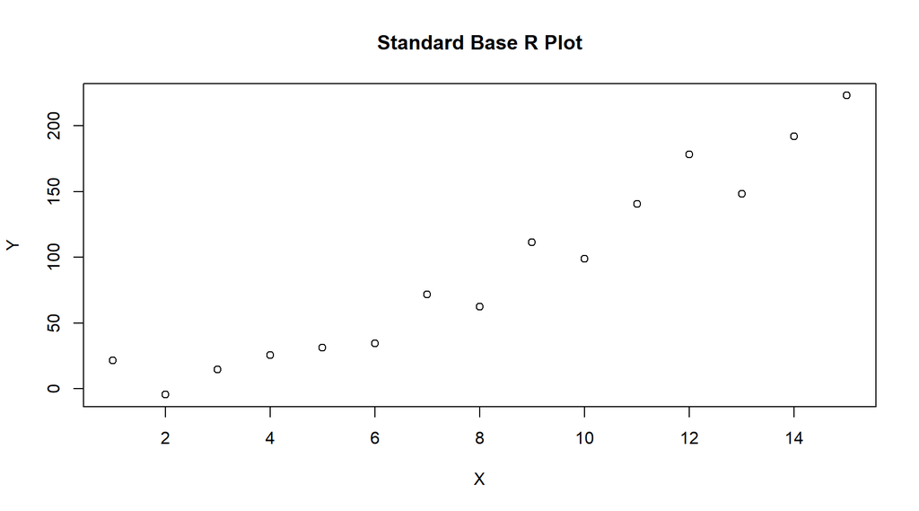

```r
# Define the main plotting function
plot_modern = function(x, y, ...) {

  # Internal function to create a stylized plot
  internal_plot = function(x, y, ...) {

    # 1. Set a soft background color for the plot area
    par(bg = "#f4f7f6", mar = c(5, 5, 4, 2))

    # 2. Initialize an empty plot window (type = "n") to lay down the grid first
    plot(x, y, type = "n", bty = "n", ...)

    # 3. Add a clean white grid
    grid(nx = NULL, ny = NULL, col = "white", lty = 1, lwd = 1.5)

    # 4. Draw a smooth trendline underneath the points
    lines(spline(x, y), col = "#b0bec5", lwd = 2)

    # 5. Plot the actual points, passing the ellipsis (...) for custom styling
    points(x, y, ...)
  }

  # Execute the internal function
  internal_plot(x, y, ...)
}


# 1. Generate sample data
set.seed(42)
x = 1:15
y = x^2 + rnorm(15, mean = 0, sd = 15)

# 2. Draw the standard base R plot (Left side)
plot(x, y,
     main = "Standard Base R Plot",
     xlab = "X", ylab = "Y")
```

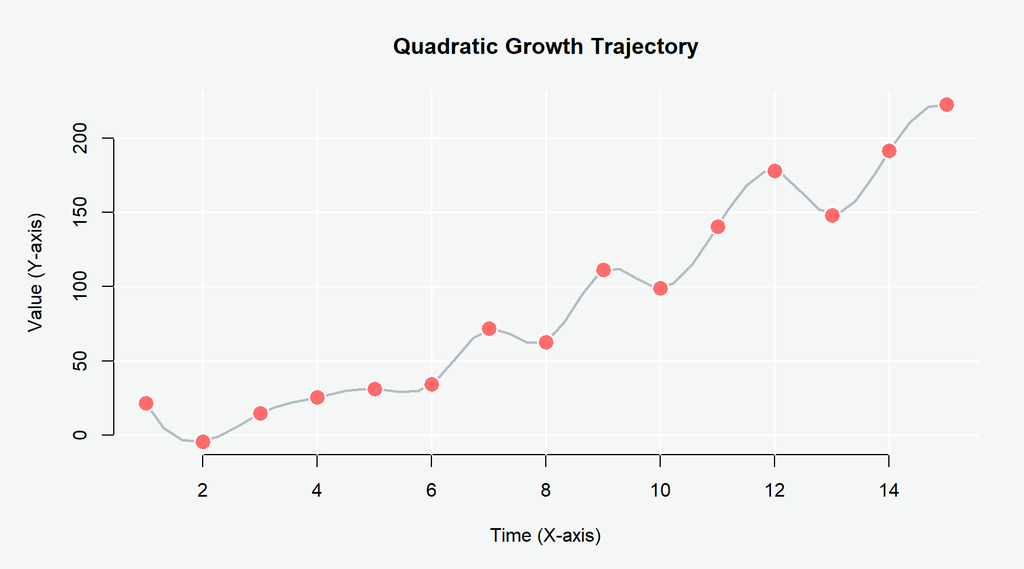

```r
# 3. Draw our custom modern plot (Right side)
plot_modern(x, y,
            main = "Quadratic Growth Trajectory",
            xlab = "Time (X-axis)",
            ylab = "Value (Y-axis)",
            col  = "#ffffff",   # Point border color
            bg   = "#ff6b6b",   # Point fill color (works with pch = 21)
            pch  = 21,          # Filled circle
            cex  = 2,           # Point size
            lwd  = 1.5,         # Border thickness
            family = "sans")    # Modern font
```

## 2.3 Multiple optional arguments with `do.call()`.

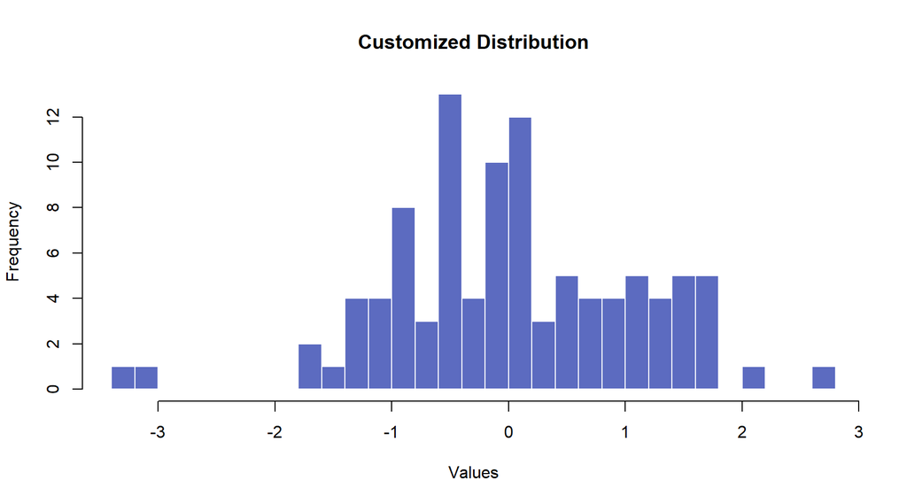

```r
# Define the main wrapper function
process_and_plot = function(data, plot_args = list(), ...) {

  # Internal: Calculate statistics using arguments from the ellipsis (...)
  calculate_summary = function(data, ...) {
    summary(data, ...)
  }

  # Internal: Create a histogram with modern default styling
  create_histogram = function(data, main = "Histogram", xlab = "Values",
                               col = "#90CAF9", border = "white", breaks = 15) {
    hist(data, main = main, xlab = xlab, col = col, border = border, breaks = breaks)
  }

  # 1. Execute summary via do.call, passing along the ellipsis arguments
  statistics = do.call(calculate_summary, list(data = data, ...))

  # 2. Inject data into plot_args and execute the histogram
  plot_args$data = data
  do.call(create_histogram, plot_args)

  # Implicitly return the statistics object
  statistics
}

# Example usage
set.seed(1812)
sample_data = rnorm(100)

# Define custom arguments to override the histogram defaults
custom_plot_args = list(
  main   = "Customized Distribution",
  col    = "#5C6BC0",
  border = "white",
  breaks = 25
)

# Call the function:
# 'digits' and 'quantile.type' flow into the ellipsis (...) for the summary
# 'custom_plot_args' flows into the histogram
example_stats = process_and_plot(
  sample_data,
  plot_args     = custom_plot_args,
  digits        = 2,
  quantile.type = 5
)
```

```r
# Print the resulting summary table
print(example_stats)
```

```
#>    Min. 1st Qu.  Median    Mean 3rd Qu.    Max.
#> -3.3000 -0.5700 -0.0094  0.0400  0.8100  2.6000
```

# 3 Data Structures and Matrix Math

## 3.1 Modifying Data Frames

Recreate the structure of a data frame and populate it cleanly.

```r
# Create a sample data frame with some initial data
sample_df = data.frame(
  ID     = c(1, 2, 3),
  Name   = c("Alice", "Bruce", "Candice"),
  Age    = c(25, 30, 35),
  Salary = c(50000, 55000, 60000)
)

# Print the sample data frame
sample_df
```

| ID | Name | Age | Salary |
| --- | --- | --- | --- |
| 1 | Alice | 25 | 50000 |
| 2 | Bruce | 30 | 55000 |
| 3 | Candice | 35 | 60000 |

```r
empty_df = sample_df[NULL, ]
empty_df
```

| ID | Name | Age | Salary |
| --- | --- | --- | --- |

```r
# Fill the empty data frame by direct assignment
empty_df[1, ] = list(ID = 4, Name = "David", Age = 28, Salary = 55000)
empty_df[2, ] = list(ID = 5, Name = "Eva", Age = 32, Salary = 62000)

empty_df
```

|  | ID | Name | Age | Salary |
| --- | --- | --- | --- | --- |
| 1 | 4 | David | 28 | 55000 |
| 2 | 5 | Eva | 32 | 62000 |

## 3.2 Matrix Multiplication & Logistic Regression

```r
# set seed
set.seed(1918)

# Define matrix A(2x3)
A = matrix(c(1, 2, 3, 4, 5, 6), nrow = 2, ncol = 3)
print(A)
```

```
#>      [,1] [,2] [,3]
#> [1,]    1    3    5
#> [2,]    2    4    6
```

```r
# Define matrix B(3x2)
B = matrix(c(7, 8, 9, 10, 11, 12), nrow = 3, ncol = 2)
print(B)
```

```
#>      [,1] [,2]
#> [1,]    7   10
#> [2,]    8   11
#> [3,]    9   12
```

```r
# Perform regular matrix multiplication(2x2)
C = A %*% B
print(C)
```

```
#>      [,1] [,2]
#> [1,]   76  103
#> [2,]  100  136
```

```r
# Define matrix D(2x2) and fill it by rows
D = matrix(c(2, 4, 6, 8), nrow = 2, ncol = 2, byrow=T)
print(D)
```

```
#>      [,1] [,2]
#> [1,]    2    4
#> [2,]    6    8
```

```r
# Perform element-wise multiplication(2x2)
F = C * D
print(F)
```

```
#>      [,1] [,2]
#> [1,]  152  412
#> [2,]  600 1088
```

```r
simple_logistic_NN=function(X,y, W0,b0, num_epochs,learning_rate, verbose=F){

# X  -> n × num_features
# y  -> n × 1
# W0 -> num_features × 1
# b0 -> 1 × 1

  # define the sigmoid function
  sigmoid = function(z) {
   1 / (1 + exp(-z))
  }

  # obtain the number of data points and features
  n=dim(X)[1]
  num_features=dim(X)[2]

  # merge weights and biases and add a column of 1s into X
  W_matrix=matrix(rbind(W0,b0), nrow=num_features+1,ncol=1)
  X_matrix=matrix(cbind(X, rep(1,n)),nrow=n,ncol=num_features+1)

  # preallocate a data frame to save losses and a matrix to save gradients
  col_names = c("Epoch", "Loss")
  df_loss = data.frame(matrix(NA, nrow = num_epochs, ncol = length(col_names)))
  colnames(df_loss) = col_names
  Gradients = matrix(NA,nrow= num_features+1, ncol=num_epochs)

# Training loop
for (epoch in 1:num_epochs)
  {

  # compute the forward pass
  z = X_matrix%*% W_matrix
  y_hat = sigmoid(z)

  # calculate loss using binary cross-entropy
  loss = -mean(y * log(y_hat) + (1 - y) * log(1 - y_hat))

  # save epoch and loss
  df_loss[epoch,]=c(epoch, loss)

  # compute gradients
  dW = t(X_matrix) %*% (y_hat - y) / n

  # save gradient
  Gradients[,epoch]=dW

  # update weights and bias
  W_matrix = W_matrix - learning_rate * dW

  if(verbose!=FALSE){
  # Print loss every verbose epochs
    if (epoch %% verbose == 0) {
      cat("Epoch:", epoch, "Loss:", loss,"Weights:", W_matrix[1:num_features,],
          "Bias:", W_matrix[num_features+1,], "\n")
                               }
                 }
   }

  l=list("W_est"     = W_matrix[1:num_features,],
         "b_est"     = W_matrix[num_features+1,],
         "Loss_DF"   = df_loss,
         "Gradients" = Gradients)
  return(l)
}
```

```r
set.seed(1986)

# Generate a synthetic dataset
n_examp_1 = 1000
X_examp_1 = matrix(rnorm(n_examp_1 * 2), ncol = 2)
y_examp_1 = as.numeric(X_examp_1[,1] + X_examp_1[,2] > 0)

# Initialize weights and bias
W0_examp_1 = matrix(runif(2), nrow = 2)
b0_examp_1 = runif(1)

logistic_NN_training_examp_1=simple_logistic_NN(X=X_examp_1, y=y_examp_1,
                                                W0=W0_examp_1,b0=b0_examp_1,
                                                num_epochs=1000,
                                                learning_rate=0.01,
                                                verbose=100)
```

```
#> Epoch: 100 Loss: 0.4321067 Weights: 0.3626608 0.9717162 Bias: 0.2820893
#> Epoch: 200 Loss: 0.3857622 Weights: 0.5567836 1.056564 Bias: 0.2469912
#> Epoch: 300 Loss: 0.351951 Weights: 0.7207754 1.134028 Bias: 0.2190585
#> Epoch: 400 Loss: 0.3262268 Weights: 0.8619835 1.206138 Bias: 0.1967264
#> Epoch: 500 Loss: 0.3059498 Weights: 0.9856042 1.274081 Bias: 0.1787698
#> Epoch: 600 Loss: 0.289491 Weights: 1.095368 1.338592 Bias: 0.1642525
#> Epoch: 700 Loss: 0.2758048 Weights: 1.194004 1.40016 Bias: 0.1524602
#> Epoch: 800 Loss: 0.2641951 Weights: 1.283555 1.459134 Bias: 0.1428455
#> Epoch: 900 Loss: 0.2541826 Weights: 1.365575 1.515776 Bias: 0.1349851
#> Epoch: 1000 Loss: 0.2454275 Weights: 1.441269 1.570297 Bias: 0.1285489
```

```r
# Print final weights and bias
cat("Estimated Weights:", logistic_NN_training_examp_1$W_est, "\n")
```

```
#> Estimated Weights: 1.441269 1.570297
```

```r
cat("Estimated Bias:", logistic_NN_training_examp_1$b_est, "\n")
```

```
#> Estimated Bias: 0.1285489
```

## 3.3 Singular Value Decomposition (SVD) from Scratch

```r
svd_custom = function(A) {
  # Check if A is a matrix
  if (!is.matrix(A)) stop("Input must be a matrix")

  # Step 1: Compute A^T * A
  AtA = t(A) %*% A

  # Step 2: Eigen decomposition of A^T * A
  eigen_AtA = eigen(AtA)

  # Eigenvalues and eigenvectors
  eigenvalues = eigen_AtA$values
  V = eigen_AtA$vectors

  # Step 3: Compute singular values
  singular_values = sqrt(eigenvalues)

  # Step 4: Compute U matrix
  U = matrix(0, nrow = nrow(A), ncol = nrow(A))
  for (i in 1:nrow(A)) {
    if (singular_values[i] != 0) {
      U[, i] = (A %*% V[, i]) / singular_values[i]
    }
  }

  # Step 5: Construct Sigma matrix
  Sigma = diag(singular_values)

  # Return the SVD components
  list(U = U, Sigma = Sigma, V = V)
}
```

```r
set.seed(1903)

A = matrix(rnorm(9), nrow = 3, ncol = 3)
svd_result =svd_custom(A)

# UVT^t == A (evaluates to TRUE)
all.equal(svd_result$U%*%svd_result$Sigma%*%t(svd_result$V), A)
```

```
#> [1] TRUE
```

## 3.4 Pre-allocate lists

```r
# Preallocate the empty list with 3 elements
n    = 3
list = vector("list", length = n)

# Fill in the first element with another list
list[[1]] = list(a = 5, b = 8, c = 13)

# Fill in the second element with a data frame
list[[2]] = data.frame(Name = c("Zu", "Georges"), Age = c(3, 14))

# Fill in the third element with a vector
list[[3]] = c(21, 34, 55, 89, 144)

list[[1]]$a
```

```
#> [1] 5
```

```r
list[[2]]$Age
```

```
#> [1]  3 14
```

```r
list[[3]]
```

```
#> [1]  21  34  55  89 144
```

## 3.5 Python-Like Dictionaries in R

Use environments for reference semantics and O(1) lookup.

```r
# First way using an environment
dict_env   = new.env()

# Assign key-value pairs to the environment
dict_env$a = 2
dict_env$b = 7
dict_env$c = 1

# Add a new key-value pair
dict_env$d = 8

# Modify an existing value
dict_env$a = 2

# List all objects in the environment
ls(dict_env)
```

```
#> [1] "a" "b" "c" "d"
```

```r
# Get a value by key
get("c", envir = dict_env)
```

```
#> [1] 1
```

```r
# generates a set of 100 colors using the rainbow function.
cols = rainbow(100)

# create a sequence of the first 100 odd numbers starting from 1.
numb = seq(1,200,2)

# preallocate three lists to store the colors, the numbers, and the indices
col_vals = vector("list",100)
num_vals = vector("list",100)
ind_vals = vector("list",100)

# iterate
for(c in 1:length(numb)){
  col_vals[[c]] = cols[c]
  num_vals[[c]] = numb[c]
  ind_vals[[c]] = c
}

# retrieve the color associated with the number 157 ("#AD00FF")
col_vals[[which(num_vals==157)]]
```

```
#> [1] "#AD00FF"
```

```r
# find the number that corresponds to the color "#AD00FF" (157)
num_vals[[which(col_vals=="#AD00FF")]]
```

```
#> [1] 157
```

```r
#check if the color and the number are associated with the same index (TRUE)
ind_vals[[which(col_vals=="#AD00FF")]]==ind_vals[[which(num_vals==157)]]
```

```
#> [1] TRUE
```

## 3.6 Vectors

```r
nums   = c(1, 2, 3)               # numeric
chars  = c("a", "b", "c")         # character
logic  = c(TRUE, FALSE, TRUE)     # logical
seq_10 = 1:10                     # integer sequence
rep_pi = rep(pi, 3)               # repeat a value
```

```r
x = 1:5
y = seq(10, 50, 10)

x + y        # 11 22 33 44 55
```

```
#> [1] 11 22 33 44 55
```

```r
x^2 + log(y) # combined numeric ops
```

```
#> [1]  3.302585  6.995732 12.401197 19.688879 28.912023
```

```r
vals = c(4, 7, 11, 3, 9)

# Keep elements > 5
vals[vals > 5]                  # 7 11 9
```

```
#> [1]  7 11  9
```

```r
# Replace outliers with NA
vals[vals > 10] = NA           # 4 7 NA 3 9
print(vals)
```

```
#> [1]  4  7 NA  3  9
```

# 4 Vectorized Iterations

R’s `apply` family avoids explicit loops with concise, vectorized C-level execution.

```r
# Sample 4×3 matrix
mat = matrix(1:12, nrow = 4, byrow = TRUE)

# Column means
apply(mat, 2, mean)
```

```
#> [1] 5.5 6.5 7.5
```

```r
# Row standard deviations
apply(mat, 1, sd)
```

```
#> [1] 1 1 1 1
```

```r
set.seed(1942)

# 1. Create a list of score vectors -----------------------------
scores = lapply(1:5, \(i) rnorm(50, mean = 70 + i * 5, sd = 8))
names(scores) = paste0("Class_", 1:5)

# 2. Compute the mean score for every class ---------------------
class_means = lapply(scores, mean)

class_means
```

```
#> $Class_1
#> [1] 74.04006
#>
#> $Class_2
#> [1] 78.34366
#>
#> $Class_3
#> [1] 84.09832
#>
#> $Class_4
#> [1] 90.77986
#>
#> $Class_5
#> [1] 95.59702
```

```r
# Create 3 normally distributed vectors with different means and SDs
set.seed(1914)
params = data.frame(mu = c(0, 5, 10), sd = c(1, 2, 3))

samples = mapply(
  FUN = rnorm,
  n   = 5,                  # recycled for each call
  mean = params$mu,
  sd   = params$sd,
  SIMPLIFY = FALSE          # keep as list of vectors
)

str(samples)
```

```
#> List of 3
#>  $ : num [1:5] -0.379 0.13 0.334 -1.887 2.051
#>  $ : num [1:5] 10.09 4.61 7.11 1.09 5.21
#>  $ : num [1:5] 13.17 11.02 8.87 9.4 9.94
```

```r
nums = list(a = 1:4, b = 5:7, c = 8:9)

# Sums each element returning a numeric vector
sapply(nums, sum)
```

```
#>  a  b  c
#> 10 18 17
```

```r
vec = 1:6
sapply(vec, function(x) x^2)
```

```
#> [1]  1  4  9 16 25 36
```

# 5 Parallel Computing

```r
library(parallel)
n_cores = max(1L, detectCores() - 1L)
print(n_cores)
```

```
#> [1] 31
```

Use `parLapply` for cross-platform parallel execution, or `mclapply` for Unix-based systems.

```r
# Expensive function: Monte Carlo estimate of pi
estimate_pi = function(n = 1e6) {
  x = runif(n)
  y = runif(n)
  mean(x^2 + y^2 <= 1) * 4
}

n_rep = 30

# ---------------------------------------------------------
# 1. SEQUENTIAL RUN
# ---------------------------------------------------------
set.seed(1986)

t_seq = system.time({
  seq_results = lapply(1:n_rep, function(i) {
    t0 = proc.time()["elapsed"]
    pi_est = estimate_pi()

    # Return both the estimate and the time it took
    data.frame(run = i, pi_est = pi_est, elapsed = proc.time()["elapsed"] - t0)
  })
})

# Bind into a single data frame
seq_df = do.call(rbind, seq_results)

# ---------------------------------------------------------
# 2. PARALLEL RUN
# ---------------------------------------------------------
n_cores = max(1, detectCores() - 1)
cl = makeCluster(n_cores)
clusterExport(cl, varlist = "estimate_pi")

set.seed(1986)

t_par = system.time({
  par_results = parLapply(cl, 1:n_rep, function(i) {
    t0 = proc.time()["elapsed"]
    pi_est = estimate_pi()

    # Return both the estimate and the time it took
    data.frame(run = i, pi_est = pi_est, elapsed = proc.time()["elapsed"] - t0)
  })
})

stopCluster(cl)

# Bind into a single data frame
par_df = do.call(rbind, par_results)

# ---------------------------------------------------------
# 3. COMPARE RESULTS
# ---------------------------------------------------------
# Check if the estimates are mathematically equivalent
all.equal(seq_df$pi_est, par_df$pi_est)
```

```
#> [1] "Mean relative difference: 0.0005693522"
```

```r
# Print the timing results
cat("Total Sequential Time:     ", round(t_seq["elapsed"], 3), "seconds\n")
```

```
#> Total Sequential Time:      1.54 seconds
```

```r
cat("Total Parallel Time:       ", round(t_par["elapsed"], 3), "seconds\n\n")
```

```
#> Total Parallel Time:        0.11 seconds
```

```r
cat("Avg Sequential per run:    ", round(mean(seq_df$elapsed), 3), "seconds\n")
```

```
#> Avg Sequential per run:     0.051 seconds
```

```r
cat("Avg Parallel per run:      ", round(mean(par_df$elapsed), 3), "seconds\n")
```

```
#> Avg Parallel per run:       0.079 seconds
```

```r
# Install if needed: install.packages(c("future", "future.apply"))
library(future)
library(future.apply)

# 1. Define the workhorse function
estimate_pi = function(n = 1e6) {
  mean(runif(n)^2 + runif(n)^2 <= 1) * 4
}

n_rep = 20

# 2. Tell R your "plan" (run asynchronously across multiple background sessions)
plan(multisession, workers = availableCores() - 1)

set.seed(1986)

# 3. Execute! future_lapply acts just like lapply, but routes traffic asynchronously
t_future = system.time({

  # future.seed = TRUE ensures random numbers are safely generated across cores
  future_results = future_lapply(1:n_rep, function(i) {
    t0 = proc.time()["elapsed"]
    pi_est = estimate_pi()
    data.frame(run = i, pi_est = pi_est, elapsed = proc.time()["elapsed"] - t0)
  }, future.seed = TRUE)

})

# 4. Bind the results
future_df = do.call(rbind, future_results)

# 5. Always explicitly close background workers when done
plan(sequential)

cat("Total Future Async Time: ", round(t_future["elapsed"], 3), "seconds\n")
```

```
#> Total Future Async Time:  0.23 seconds
```

```r
cat("Average Future Async per run: ", round(mean(future_df$elapsed), 3), "seconds\n")
```

```
#> Average Future Async per run:  0.056 seconds
```

# 6 Running Python Code in R

Execute Python scripts and pass data frames back and forth using `{reticulate}`.

```r
library(reticulate)

# Show which Python is being used
py_config()
```

```
#> python:         C:/Users/vadim/AppData/Local/R/cache/R/reticulate/uv/cache/archive-v0/hTrjH-QW50JlBG25MDlZa/Scripts/python.exe
#> libpython:      C:/Users/vadim/AppData/Local/R/cache/R/reticulate/uv/python/cpython-3.12.13-windows-x86_64-none/python312.dll
#> pythonhome:     C:/Users/vadim/AppData/Local/R/cache/R/reticulate/uv/cache/archive-v0/hTrjH-QW50JlBG25MDlZa
#> virtualenv:     C:/Users/vadim/AppData/Local/R/cache/R/reticulate/uv/cache/archive-v0/hTrjH-QW50JlBG25MDlZa/Scripts/activate_this.py
#> version:        3.12.13 (main, Apr  7 2026, 20:53:22) [MSC v.1944 64 bit (AMD64)]
#> Architecture:   64bit
#> numpy:          C:/Users/vadim/AppData/Local/R/cache/R/reticulate/uv/cache/archive-v0/hTrjH-QW50JlBG25MDlZa/Lib/site-packages/numpy
#> numpy_version:  2.4.4
#>
#> NOTE: Python version was forced by VIRTUAL_ENV
```

```r
#reticulate::py_install("pandas")
```

```r
# Run Python inline
py_run_string("
x = [1, 2, 3]
y = [i**2 for i in x]
")

# Access Python variables natively in R
py$y
py$x
```

[output not shown]

```r
np = import("numpy")

# Create NumPy arrays and compute statistics
a = np$array(c(1, 2, 3, 4, 5))
mean_a = np$mean(a)
mean_a
```

```
#> [1] 3
```

```r
# Create a standard R dataframe
r_df = data.frame(a = 1:3, b = c(4, 5, 6))
```

```python
import pandas as pd

# Pull the dataframe from R into Python
py_df = r.r_df

# Perform our Python operations
py_df['sum'] = py_df['a'] + py_df['b']
```

```r
# Pull the modified dataframe back from Python into R
final_r_df = py$py_df

print(final_r_df)
```

```
#>   a b sum
#> 1 1 4   5
#> 2 2 5   7
#> 3 3 6   9
```